# VAT_rebate_quality_china data analysis

This notebook has been generated on 2020-03-12 12:36

The objective of this notebook is to replicate the tables of this [paper](https://drive.google.com/open?id=1BG4xxFm2DAwnQTfXhVD3RVUbm-w4FoQR)

## Data source

The data source of this dataset is:

- [vat_rebate_china.gz](https://console.cloud.google.com/storage/browser/_details/chinese_data/paper_project/vat_rebate_china.gz?project=valid-pagoda-132423)

### Variable name

The variables names and labels are the following:

|  | Variables | Labels | Types |
| --- | --- | --- | --- |
| 0 | int64_field_0 | int64_field_0 | int64 |
| 1 | hs6 | hs6 | int64 |
| 2 | eligible | eligible | bool |
| 3 | geocode4_corr | geocode4_corr | int64 |
| 4 | i | i | int64 |
| 5 | distance | distance | float64 |
| 6 | id_group | id_group | int64 |
| 7 | party_id | party_id | int64 |
| 8 | goods | goods | object |
| 9 | hs4 | hs4 | int64 |
| 10 | gbt | gbt | int64 |
| 11 | t_0 | t_0 | int64 |
| 12 | t | t | int64 |
| 13 | export_unit_price | export_unit_price | float64 |
| 14 | l_q | l_q | float64 |
| 15 | c | c | int64 |
| 16 | code | code | int64 |
| 17 | quality | quality | float64 |
| 18 | density_china_ville | density_china_ville | float64 |
| 19 | herf_com_s | herf_com_s | float64 |
| 20 | herf_com_o | herf_com_o | float64 |
| 21 | average | average | float64 |
| 22 | ln_import_tax | ln_import_tax | float64 |
| 23 | ln_vat_tax | ln_vat_tax | float64 |
| 24 | vat_m | vat_m | float64 |
| 25 | vat_reb_m | vat_reb_m | float64 |
| 26 | g1 | g1 | int64 |
| 27 | g2 | g2 | int64 |
| 28 | g3 | g3 | int64 |
| 29 | g4 | g4 | int64 |
| 30 | imported_variety | imported_variety | int64 |
| 31 | g5 | g5 | int64 |
| 32 | energy | energy | int64 |
| 33 | high_tech | high_tech | int64 |
| 34 | hi_s_e1 | hi_s_e1 | int64 |
| 35 | hi_s_us1 | hi_s_us1 | int64 |
| 36 | hi_s_e2 | hi_s_e2 | int64 |
| 37 | hi_s_us2 | hi_s_us2 | int64 |
| 38 | rd_o | rd_o | float64 |
| 39 | rd_o_mean | rd_o_mean | float64 |
| 40 | h_rd_o | h_rd_o | int64 |

# Analysis

Original code from [here](https://drive.google.com/open?id=1V6klFoNaPL30YdFOAonPaQs_v9Tn5rPq)

## Load the data

Please open links below to download the necessary data, and make sure to locate them in the same path as the notebook, otherwise, change the path.

- [vat_rebate_china.gz](https://console.cloud.google.com/storage/browser/_details/chinese_data/paper_project/vat_rebate_china.gz?project=valid-pagoda-132423)
- [baci92_2002.csv](https://console.cloud.google.com/storage/browser/_details/chinese_data/paper_project/intermediate_files/baci92_2002.csv?project=valid-pagoda-132423)
- [city_list_final.csv](https://console.cloud.google.com/storage/browser/_details/chinese_data/paper_project/intermediate_files/city_list_final.csv?project=valid-pagoda-132423)
- [export_2002.csv](https://console.cloud.google.com/storage/browser/_details/chinese_data/paper_project/intermediate_files/export_2002.csv?project=valid-pagoda-132423)

We decided to choose this way to load the data since it does not fit our current framework. The main data has been created using stata, which makes it very complicated to reproduce and visualize the pipeline. No documentation is available as well.

```
 Hlavac, Marek (2018). stargazer: Well-Formatted Regression and Summary Statistics Tables.
 R package version 5.2.2. https://CRAN.R-project.org/package=stargazer
```

```
     No     Yes
 300197 4403767
```

# Replicate table

To check how the FE are created, please refer to [here](https://drive.google.com/open?id=1pyMKTjtGJsVOorFniQDsFWR6b8DxDXYr)

```
egen g1 = group(id_group hs6 eligible)
*egen g1 = group(id_group hs6 )
egen g2 = group(i t_0 )
egen g3 = group(c t_0)
egen g4 = group(hs4 eligible t_0)
egen g5 = group(hs6 i t_0)
```

## Table 1: Baseline

Output latex table available here

- https://www.overleaf.com/project/5e6b52424e39670001dabbb0
  - table_1

[figure not shown]

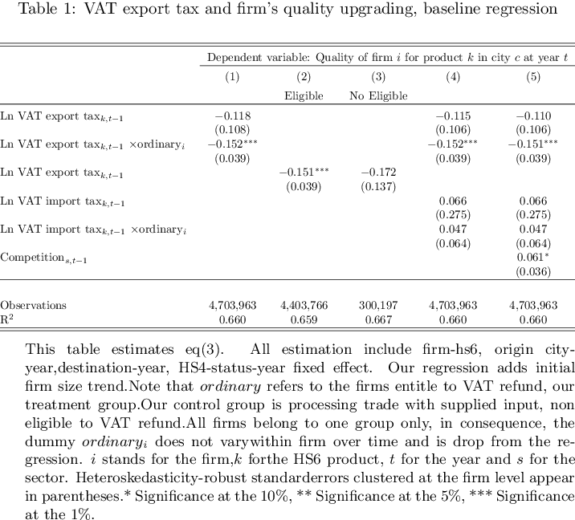

## Table 2

Output latex table available here

- https://www.overleaf.com/project/5e6b52424e39670001dabbb0
  - table_2

[figure not shown]

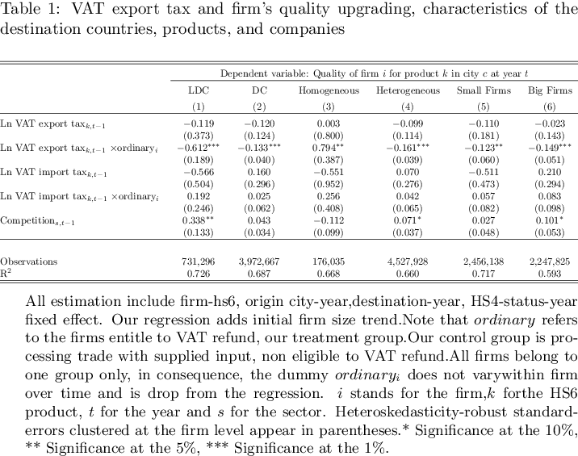

## Table 3

Output latex table available here

- https://www.overleaf.com/project/5e6b52424e39670001dabbb0
  - table_3

[figure not shown]

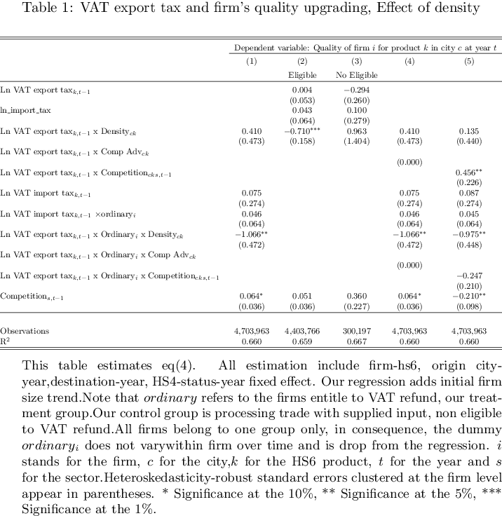

## Table 4

Output latex table available here

- https://www.overleaf.com/project/5e6b52424e39670001dabbb0
  - table_4

[figure not shown]

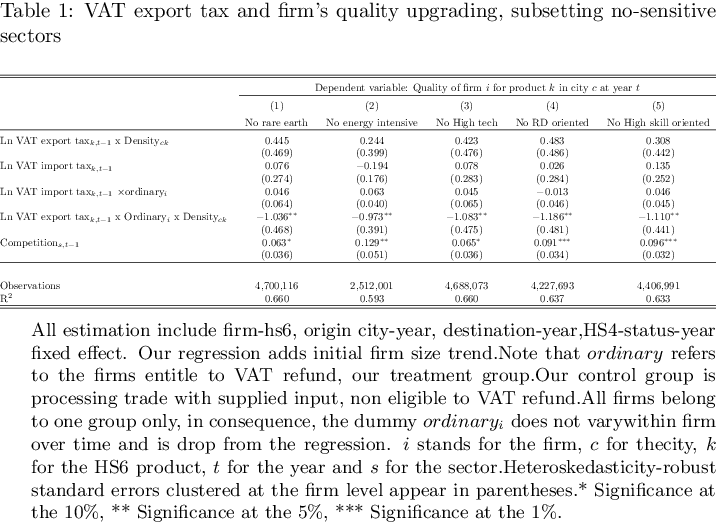

## Table 5

Output latex table available here

- https://www.overleaf.com/project/5e6b52424e39670001dabbb0
  - table_5

[figure not shown]

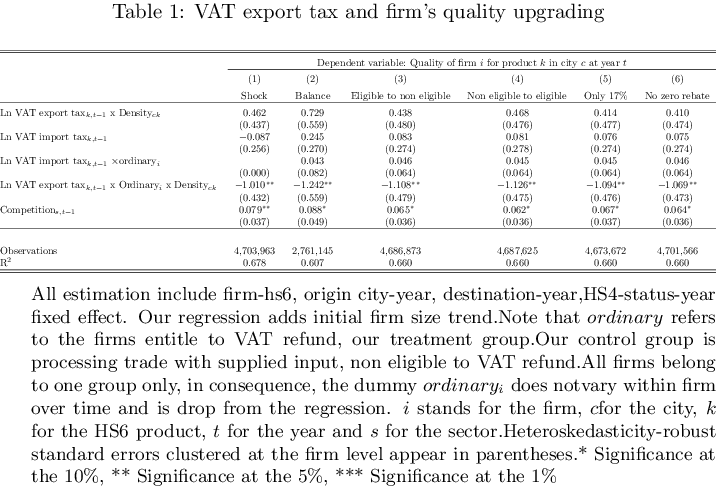

# Create Report

```
0
```

```
'/Users/thomas/Google Drive/Projects/GitHub/Repositories/VAT_rebate_quality_china/Data_analysis/00_replicate_tables/Reports/01_VAT_replicate_tables.html'
```

```
'01_VAT_replicate_tables.ipynb'
```